# HW_2 - Time Series Regression

Ceren Dündar

2022-05-12

# Homework Short Introduction

In this homework, the sales of Unloaded Gasoline Sales (target variable) for each quarter of 2007 are tried to be forecasted by using some regression methods. The data that is used includes 9 independent variables such as UGS: Unleaded gasoline sales in a given quarter, RNUV: Index showing the rate of new unleaded gasoline vehicles added to the traffic in a quarter, PU: Average price of one liter of unleaded gasoline per quarter (adjusted by index), PG: Average price of one liter of diesel gasoline per quarter (adjusted by an index), NUGV: Number of unleaded gasoline driving in traffic, NDGV: Number of diesel fuel vehicles driving in traffic (per 1000 people), GNPA: agricultural component of Gross National Product (adjusted by index), GNPC: Trade component of Gross National Product (adjusted by an index), GNP: The grand total for GNP (the sum of agriculture, trade and other components).

In following sections, required libraries will be imported, then data structure will be inspected and some data updates will come up if necessary to do improvement on models. After handling with data, it will be visualized by plotting and examined from different aspects before starting to forecast. After forecasting, the best model will be selected and explanation will be given. Lastly, prediction values for 2007 Quarters will be presented.

# Importing Libraries

```r
require(data.table)
library(stringr)
require(xlsx)
library(lubridate)
library(zoo)
library(ggplot2)
library(RcppRoll)
library(GGally)
library(skimr)
library(forecast)
library(dplyr)
```

## Importing data

Our csv data is read.

```r
data_path='C:/Users/Asus/Desktop/IE360/HW2/IE360_Spring22_HW2_data.csv'
UGSdata=fread(data_path)
```

## Data Reading

Firstly, data is read before making any change. It can be seen that some variables are numeric, some variables are character type. We want all of them numeric.

```r
head(UGSdata)
```

```
##    Quarter Unleaded Gasoline Sale (UGS)   RNUV # LPG Vehicles (NLPG)
## 1: 2000_Q1                    1 128 971 0.0146               940 000
## 2: 2000_Q2                    1 199 569 0.0205               941 000
## 3: 2000_Q3                    1 370 167 0.0207               943 500
## 4: 2000_Q4                    1 127 548 0.0163               948 000
## 5: 2001_Q1                    1 033 918 0.0071               950 000
## 6: 2001_Q2                    1 019 754 0.0051               955 000
##    Price of Unleaded Gasoline (PU) Price of Diesel Gasoline (PG)
## 1:                          469.03                        355.69
## 2:                          459.42                        344.58
## 3:                          439.98                        327.21
## 4:                          402.08                        300.67
## 5:                          411.58                        305.75
## 6:                          520.39                        374.78
##    # Unleaded Gasoline Vehicles (NUGV) # of Diesel Gasoline Vehicles (NDGV)
## 1:                           4 647 500                             281.9853
## 2:                           4 742 876                             284.0813
## 3:                           4 840 931                             286.7169
## 4:                           4 919 685                             288.3137
## 5:                           4 954 754                             287.6237
## 6:                           4 980 204                             287.8814
##    GNP Agriculture GNP Commerce  GNP Total
## 1:       1 040 173    3 483 132 18 022 686
## 2:       1 760 460    4 525 451 21 797 130
## 3:       6 974 808    5 915 204 30 050 207
## 4:       3 267 125    4 929 778 24 480 153
## 5:       1 004 528    3 418 387 15 832 648
## 6:       1 449 357    4 359 831 20 296 918
```

```r
str(UGSdata)
```

```
## Classes 'data.table' and 'data.frame':   32 obs. of  11 variables:
##  $ Quarter                             : chr  "2000_Q1" "2000_Q2" "2000_Q3" "2000_Q4" ...
##  $ Unleaded Gasoline Sale (UGS)        : chr  "1 128 971" "1 199 569" "1 370 167" "1 127 548" ...
##  $ RNUV                                : num  0.0146 0.0205 0.0207 0.0163 0.0071 0.0051 0.0041 0.0048 0.0012 0.0032 ...
##  $ # LPG Vehicles (NLPG)               : chr  "940 000" "941 000" "943 500" "948 000" ...
##  $ Price of Unleaded Gasoline (PU)     : num  469 459 440 402 412 ...
##  $ Price of Diesel Gasoline (PG)       : num  356 345 327 301 306 ...
##  $ # Unleaded Gasoline Vehicles (NUGV) : chr  "4 647 500" "4 742 876" "4 840 931" "4 919 685" ...
##  $ # of Diesel Gasoline Vehicles (NDGV): num  282 284 287 288 288 ...
##  $ GNP Agriculture                     : chr  "1 040 173" "1 760 460" "6 974 808" "3 267 125" ...
##  $ GNP Commerce                        : chr  "3 483 132" "4 525 451" "5 915 204" "4 929 778" ...
##  $ GNP Total                           : chr  "18 022 686" "21 797 130" "30 050 207" "24 480 153" ...
##  - attr(*, ".internal.selfref")=<externalptr>
```

## Data Manipulation

Firstly, all variables are converted to numeric characters (NLPG, NUGV, GNP Agriculture etc. were character types and they also should be numeric). And, short names are given for each column.

```r
UGSdata=as.data.frame(apply(UGSdata,2,function(x)gsub('\\s+', '',x)))
UGSdata[,2]=as.numeric(as.character(UGSdata[,2]))
UGSdata[,3]=as.numeric(as.character(UGSdata[,3]))
UGSdata[,4]=as.numeric(as.character(UGSdata[,4]))
UGSdata[,5]=as.numeric(as.character(UGSdata[,5]))
UGSdata[,6]=as.numeric(as.character(UGSdata[,6]))
UGSdata[,7]=as.numeric(as.character(UGSdata[,7]))
UGSdata[,8]=as.numeric(as.character(UGSdata[,8]))
UGSdata[,9]=as.numeric(as.character(UGSdata[,9]))
UGSdata[,10]=as.numeric(as.character(UGSdata[,10]))
UGSdata[,11]=as.numeric(as.character(UGSdata[,11]))
UGSdata[,12:13]=data.frame(str_split_fixed(UGSdata[,1], "_", 2))
UGSdata[,12]=as.numeric(as.character(UGSdata[,12]))
colnames(UGSdata)= c("Quarters","UGS","RNUV","NLPG","PU","PG","NUGV","NDGV","GNPA","GNPC","GNPT","Years","Quarter")
```

Manipulating the data helps us to check “seasonal changes” in time series concept for both quarters and years separately with new two columns.

Now, updated data structure can be seen:

```r
str(UGSdata)
```

```
## 'data.frame':    32 obs. of  13 variables:
##  $ Quarters: chr  "2000_Q1" "2000_Q2" "2000_Q3" "2000_Q4" ...
##  $ UGS     : num  1128971 1199569 1370167 1127548 1033918 ...
##  $ RNUV    : num  0.0146 0.0205 0.0207 0.0163 0.0071 0.0051 0.0041 0.0048 0.0012 0.0032 ...
##  $ NLPG    : num  940000 941000 943500 948000 950000 ...
##  $ PU      : num  469 459 440 402 412 ...
##  $ PG      : num  356 345 327 301 306 ...
##  $ NUGV    : num  4647500 4742876 4840931 4919685 4954754 ...
##  $ NDGV    : num  282 284 287 288 288 ...
##  $ GNPA    : num  1040173 1760460 6974808 3267125 1004528 ...
##  $ GNPC    : num  3483132 4525451 5915204 4929778 3418387 ...
##  $ GNPT    : num  18022686 21797130 30050207 24480153 15832648 ...
##  $ Years   : num  2000 2000 2000 2000 2001 ...
##  $ Quarter : chr  "Q1" "Q2" "Q3" "Q4" ...
```

```r
setDT(UGSdata)
```

## Visualization of the Data

Before forecasting step, UGS(target variable) time series, mean and variance are plotted and visualized. Some comments are made.

### Time Series Plot of UGS Sales

Here is my comments for UGS time series, mean and variance plots at below: According to time series plot, it seems UGS has seasonality effect over time. UGS value is decreasing as time passes, so it can be said that it is “time dependent”. It has a decreasing trend for each 4 quarter time period. With respect to mean series of UGS, mean has decreasing pattern which indicates non-stationary data. On the other hand, with respect to variance series of UGS, it seems randomly changing and independent from the time, so variance is stationary.

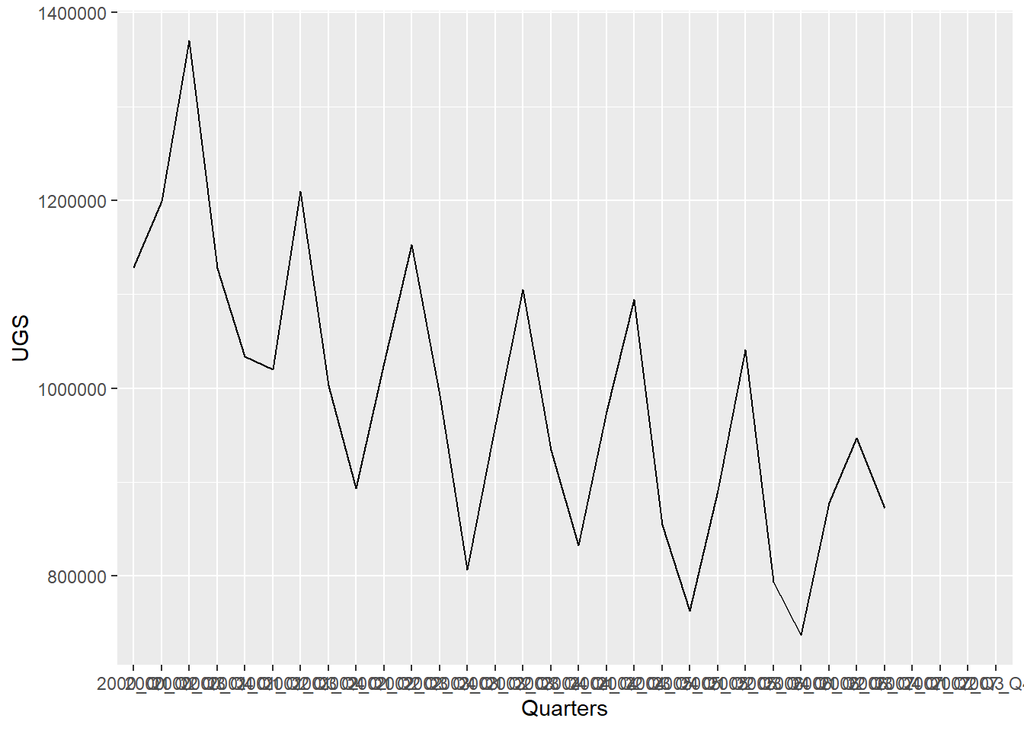

```r
ggplot(UGSdata,aes(x=Quarters,y=UGS, group=1))  +geom_line()
```

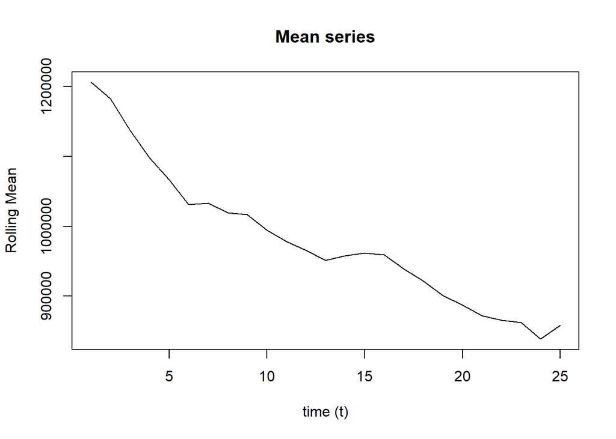

```r
mean_series=roll_mean(UGSdata$UGS[1:28],4,align='left')
var_series=roll_var(UGSdata$UGS[1:28],4,align='left')
plot(mean_series,
     type='l',col='black',
     xlab = "time (t)",
     ylab = "Rolling Mean",
     main = "Mean series")
```

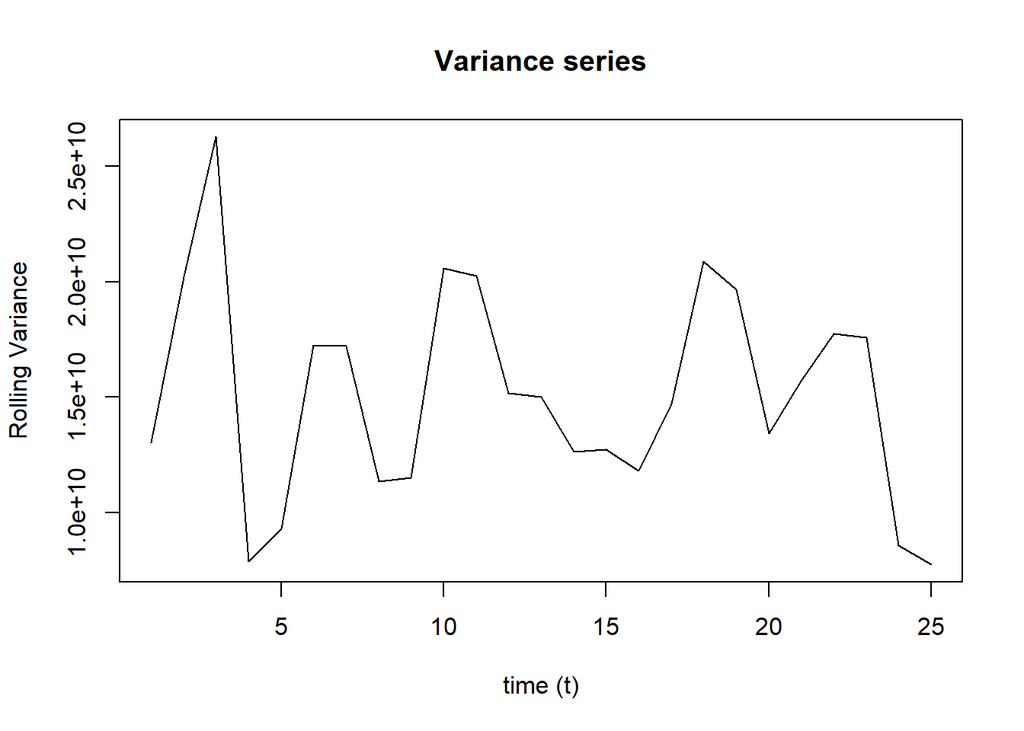

```r
plot(var_series,
     type='l',col='black',
     xlab = "time (t)",
     ylab = "Rolling Variance",
     main = "Variance series")
```

## Autocorrelation

To sum up with all, we can say that data is non-stationary.

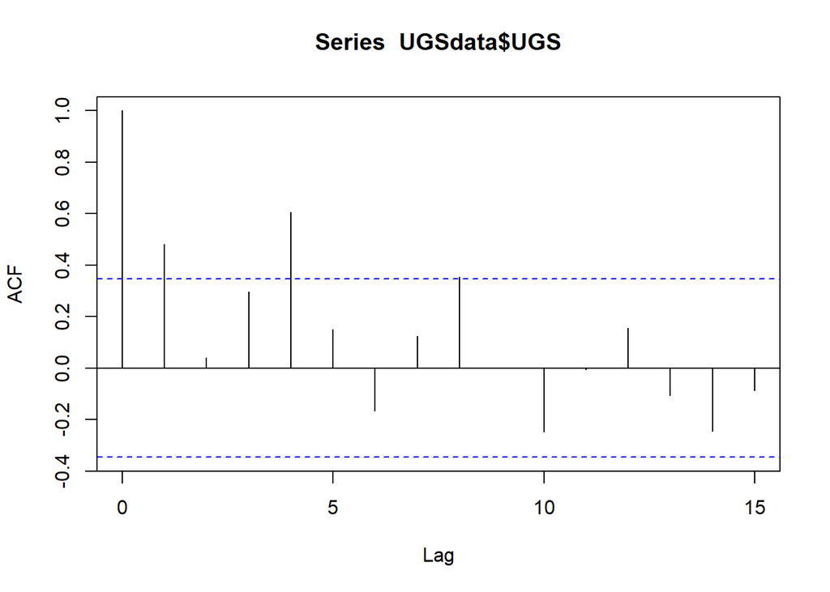

```r
acf(UGSdata$UGS,na.action = na.pass)
```

## Defining Trend Variable and Lagged Variable

Trend column is added which is 1…N

```r
UGSdata[,trend:=1:.N]
```

Lag one is added as a lagged variable. (Lag four and eight are related with quarter relation, so just add lag one to use in future steps).

```r
UGSdata[,lag1:=shift(UGSdata$UGS,1)]
```